# Team2_DIA1_LEMOAL_AURUS

## Music Dataset

Student : Aurelien AURUS, Stevn LE MOAL

#### Introduction

A dataset of 1613 songs with attributes from Spotify for some users

Every song is labeled in the column save:

“1” means the user likes the song . “0” means he doesn’t like it. There are 16 columns in the dataset. 2 of them describe the song : song ’s name and artist. Another, the save column, is the target variable

The other 13 columns are the audio features of a song.

More info : https://developer.spotify.com/documentation/web-api/reference/#/operations/get-audio-features

#### Problematique

We want to predict if a user, will like or not a music. The evaluation metric for this competition is the accuracy (proportion of the correct predictions)

#### Data Processing

##### Library and Data Overview

```r
library(magrittr)
library("dplyr")
library("ggplot2")
library(tidyr)
library(corrplot)
library(rpart)
#library(MASS)
library(caTools)
library(rpart.plot)
library(randomForest)
library(gbm)
library(xgboost)
library(caret)
library(ipred)
library(ROCR)
library(FactoMineR)
library(factoextra)
library(mlbench)
library(e1071)
library(MLmetrics)
set.seed(2)
```

```r
data = read.csv("C:/Users/Papa/Documents/R_eval/train.csv")
head(data)
```

```
##   acousticness danceability duration_ms energy instrumentalness key liveness
## 1     0.000294        0.827      352341  0.462         0.543000   8   0.0886
## 2     0.021900        0.630      222546  0.684         0.001080  11   0.1030
## 3     0.063900        0.742      256693  0.945         0.165000   5   0.1310
## 4     0.031000        0.510      210013  0.747         0.000000   5   0.2330
## 5     0.014400        0.529      179200  0.739         0.000255   9   0.3900
## 6     0.151000        0.633      321627  0.850         0.000000   5   0.0556
##   loudness mode speechiness   tempo time_signature valence
## 1  -10.673    1      0.0623 123.994              4   0.341
## 2   -6.740    0      0.0399 142.952              4   0.881
## 3   -6.445    1      0.0428 112.977              4   0.748
## 4   -4.124    1      0.0651 125.951              4   0.349
## 5   -5.356    0      0.0543 149.915              4   0.403
## 6   -5.915    0      0.3440  97.933              4   0.761
##                              song_title           artist save
## 1 Pleasure Power (DJ Smash Disco Remix)      Afrolicious    1
## 2             너와의 공식 Love Equation 플랫핏 Flat Feet    0
## 3                             Uncle ACE     Blood Orange    1
## 4                  Heroes (we could be)           Alesso    0
## 5                      Afraid, Unafraid      SLUMBERJACK    0
## 6                                 HLM 3          Lunatic    1
```

acousticness : A confidence measure from 0 to 1 of whether the song is acoustic. 1.0 represents high confidence the song is acoustic

danceability : measure from 0.0 to 1.0 describes how suitable a song is for dancing. A value of 0 is least danceable and 1 is most danceable

duration_ms : The duration of the song in milliseconds

energy : Energy is a measure from 0 to 1 and represents a perceptual measure of intensity and activity

instrumentalness : It predicts whether a song contains no vocals. The closer the instrumentals value is to 1.0

key : The key the song is in. Integers map to pitches using standard Pitch Class notation. Eg. 0= C,1=C# etc..

liveness : Detects the presence of an audience in the recording. A value above 0.8 provides a strong likelihood that the song is live.

loudness : The overall loudness of a song in decibels(dB)

mode : It indicates the modality(major or minor) of the song

speechiness : Speechiness detects the presence of spoken words in a song . The more exclusively speech-like the recording, the closer to 1.0 the attribute value.

tempo : The overall estimated tempo of a song in beats per minute (BPM)

time_signature : An estimated overall time signature of a song .

valence : A measure from 0.0 to 1.0 describing the musical positiveness conveyed by a song .

```r
summary(data)
```

```
##   acousticness        danceability     duration_ms          energy
##  Min.   :0.0000028   Min.   :0.1220   Min.   :  16042   Min.   :0.0148
##  1st Qu.:0.0096900   1st Qu.:0.5110   1st Qu.: 199904   1st Qu.:0.5610
##  Median :0.0626000   Median :0.6310   Median : 228467   Median :0.7140
##  Mean   :0.1872243   Mean   :0.6189   Mean   : 247344   Mean   :0.6814
##  3rd Qu.:0.2650000   3rd Qu.:0.7410   3rd Qu.: 271560   3rd Qu.:0.8440
##  Max.   :0.9950000   Max.   :0.9840   Max.   :1004627   Max.   :0.9970
##  instrumentalness         key            liveness         loudness
##  Min.   :0.0000000   Min.   : 0.000   Min.   :0.0219   Min.   :-33.097
##  1st Qu.:0.0000000   1st Qu.: 2.000   1st Qu.:0.0915   1st Qu.: -8.407
##  Median :0.0000644   Median : 6.000   Median :0.1270   Median : -6.258
##  Mean   :0.1318193   Mean   : 5.402   Mean   :0.1924   Mean   : -7.092
##  3rd Qu.:0.0473000   3rd Qu.: 9.000   3rd Qu.:0.2510   3rd Qu.: -4.757
##  Max.   :0.9760000   Max.   :11.000   Max.   :0.9690   Max.   : -0.307
##       mode         speechiness          tempo        time_signature
##  Min.   :0.0000   Min.   :0.02310   Min.   : 47.86   Min.   :1.000
##  1st Qu.:0.0000   1st Qu.:0.03740   1st Qu.:100.52   1st Qu.:4.000
##  Median :1.0000   Median :0.05430   Median :121.02   Median :4.000
##  Mean   :0.6138   Mean   :0.09326   Mean   :121.59   Mean   :3.969
##  3rd Qu.:1.0000   3rd Qu.:0.10700   3rd Qu.:137.17   3rd Qu.:4.000
##  Max.   :1.0000   Max.   :0.81600   Max.   :219.33   Max.   :5.000
##     valence        song_title           artist               save
##  Min.   :0.0348   Length:1613        Length:1613        Min.   :0.0000
##  1st Qu.:0.2990   Class :character   Class :character   1st Qu.:0.0000
##  Median :0.5010   Mode  :character   Mode  :character   Median :1.0000
##  Mean   :0.5011                                         Mean   :0.5096
##  3rd Qu.:0.6940                                         3rd Qu.:1.0000
##  Max.   :0.9920                                         Max.   :1.0000
```

Number of null value by variable

```r
sapply(data, function(x) sum(is.na(x)))
```

```
##     acousticness     danceability      duration_ms           energy
##                0                0                0                0
## instrumentalness              key         liveness         loudness
##                0                0                0                0
##             mode      speechiness            tempo   time_signature
##                0                0                0                0
##          valence       song_title           artist             save
##                0                0                0                0
```

Number of unique value by variable

```r
sapply(data, function(x) length(unique(x)))
```

```
##     acousticness     danceability      duration_ms           energy
##             1195              593             1549              672
## instrumentalness              key         liveness         loudness
##              916               12              721             1485
##             mode      speechiness            tempo   time_signature
##                2              722             1552                4
##          valence       song_title           artist             save
##              774             1570             1125                2
```

Distribution of each predictor (depending on the range of the value)

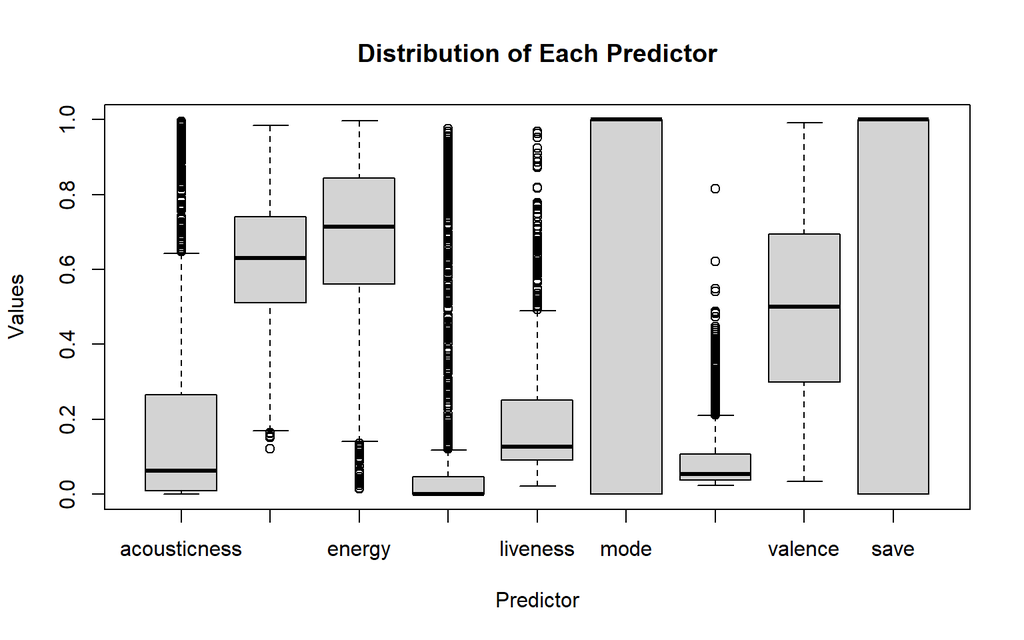

```r
data %>%
  select_if(is.numeric) %>%
  select(-c(duration_ms, tempo, loudness,key,time_signature)) %>%
  boxplot(main = 'Distribution of Each Predictor', xlab = 'Predictor', ylab = 'Values')
```

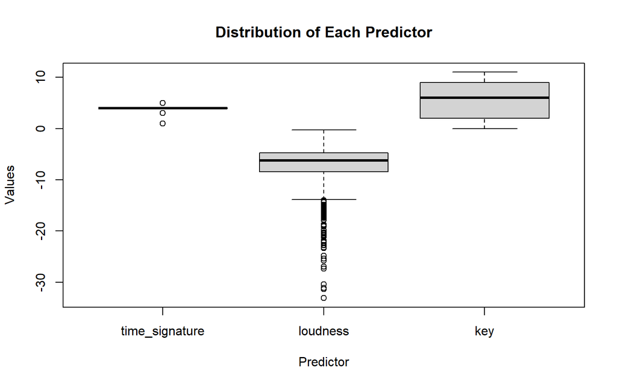

```r
data %>%
   select_if(is.numeric) %>%
   select(c(time_signature, loudness,key)) %>%
   boxplot(main = 'Distribution of Each Predictor', xlab = 'Predictor', ylab = 'Values')
```

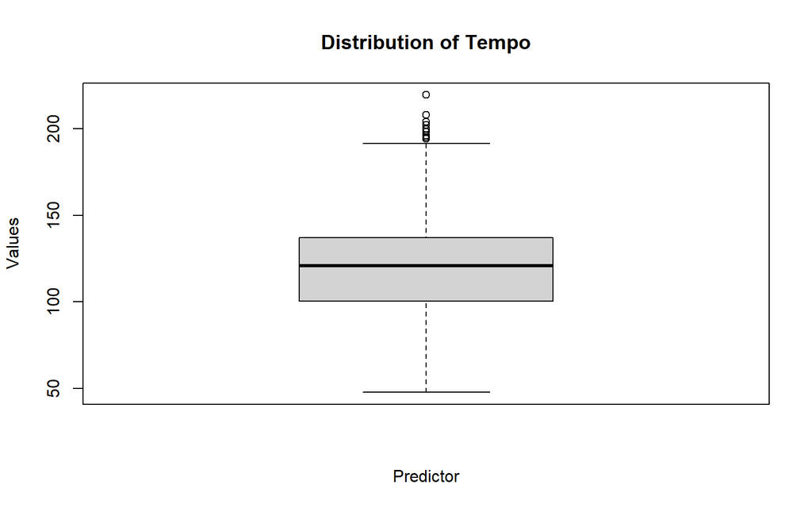

```r
data %>%
   select_if(is.numeric) %>%
   select(c(tempo)) %>%
   boxplot(main = 'Distribution of Tempo', xlab = 'Predictor', ylab = 'Values')
```

It’s interesting to see the value of the variable to see if they have a lot of high/low value.

We see if the features have outliers and we use the t-test to know if we can remove them :

```r
out_acc = boxplot.stats(data$acousticness)$out
out_dan = boxplot.stats(data$danceability)$out
out_dur = boxplot.stats(data$duration_ms)$out
out_ene = boxplot.stats(data$energy)$out
out_ins = boxplot.stats(data$instrumentalness)$out
out_liv = boxplot.stats(data$liveness)$out
out_lou = boxplot.stats(data$loudness)$out
out_spe = boxplot.stats(data$speechiness)$out
out_tem = boxplot.stats(data$tempo)$out

data.outliers = data %>% filter(acousticness >= out_acc |
                           danceability >= out_dan |
                           duration_ms >= out_dur |
                           energy >= out_ene |
                           instrumentalness >= out_ins |
                           liveness >= out_liv |
                           loudness >= out_lou |
                           speechiness >= out_spe|
                           tempo >= out_tem
                          )
data.clean <- data %>% filter(!song_title %in% data.outliers$song_title)
```

```r
t.test(data$save, data.outliers$save)
```

```
##
##  Welch Two Sample t-test
##
## data:  data$save and data.outliers$save
## t = -0.017951, df = 3223, p-value = 0.9857
## alternative hypothesis: true difference in means is not equal to 0
## 95 percent confidence interval:
##  -0.03484626  0.03421399
## sample estimates:
## mean of x mean of y
## 0.5096094 0.5099256
```

We see that p > 0,05 so it is not safe to assume that the strengths of the normal and outlier groups differ.

```r
#data.clean %>%
#    ggplot(aes(x = duration_ms, y = save)) +
#    geom_point() +
#    geom_point(data = data.outliers, aes(x = duration_ms, y = save), col = 'red') +
#    labs(
#        title = 'Distribution of Save : Original vs outlier (red)',
#        x = 'duration',
#        y = 'Save')
```

# Distribution of each feature (density graph)

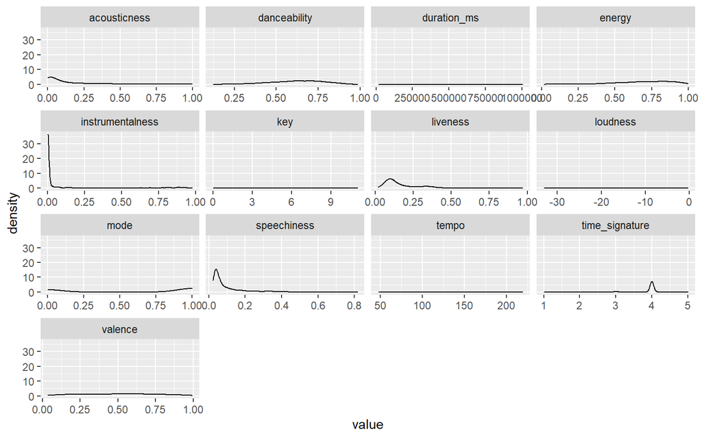

```r
data %>%
    select_if(is.numeric) %>%
    pivot_longer(cols = -save, names_to = 'predictor') %>%
    ggplot(aes(x = value)) +
    geom_density() +
    facet_wrap(~predictor, scales = 'free_x')
```

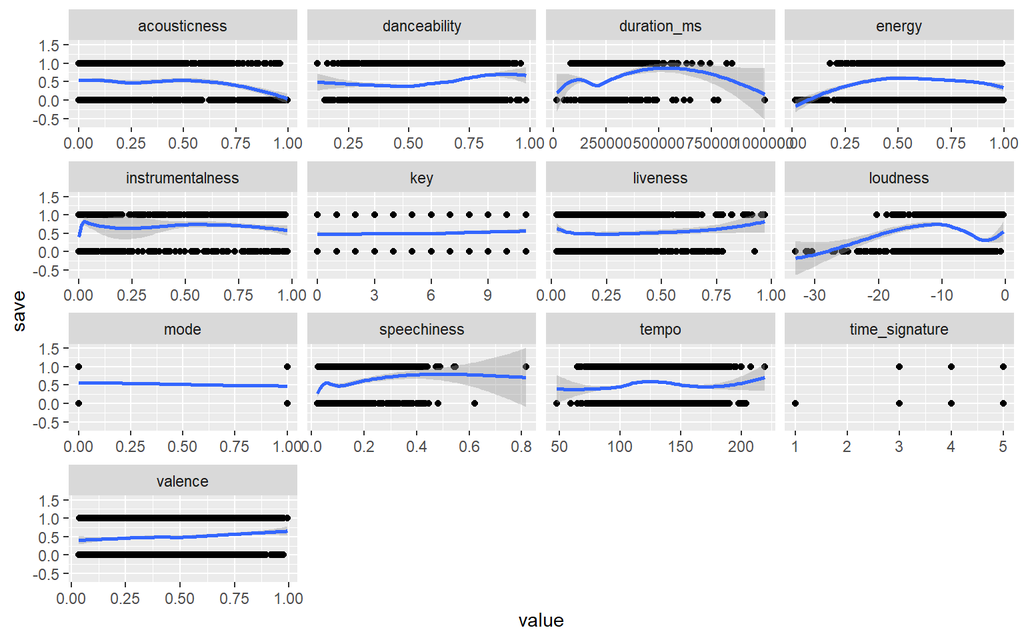

```r
data %>%
    select_if(is.numeric) %>%
    pivot_longer(cols = -save, names_to = 'predictor') %>%
    ggplot(aes(x = value, y = save)) +
    geom_point() +
    geom_smooth(method = 'loess', formula = 'y ~ x') +
    facet_wrap(~predictor, scales = 'free_x')
```

Some variable like key and mode are really uniform. The variable’ graphs will help use choice our predictors (like energy..) since we want ‘something’ linear.

```r
#ggplot(data = data, aes(x = (save))) +
#  geom_density(fill = "red", color = "black") +
#  labs( title = "Like Distribution", x = "Variable")
```

One of the approach that could be use is scaling (but for the model, we didnt use the scale ones)

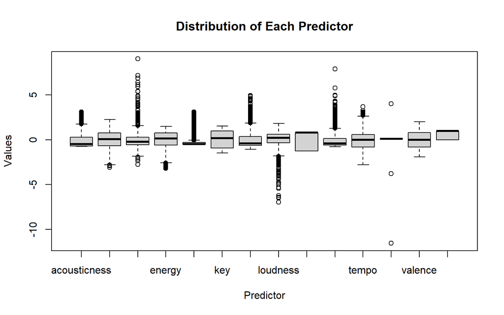

```r
data_scale = data %>% select_if(is.numeric)
data_scale[,-c(14)] = scale(data_scale[,-c(14)], center = TRUE, scale = TRUE)
data_scale %>%
   boxplot(main = 'Distribution of Each Predictor', xlab = 'Predictor', ylab = 'Values')
```

Distribution of variables

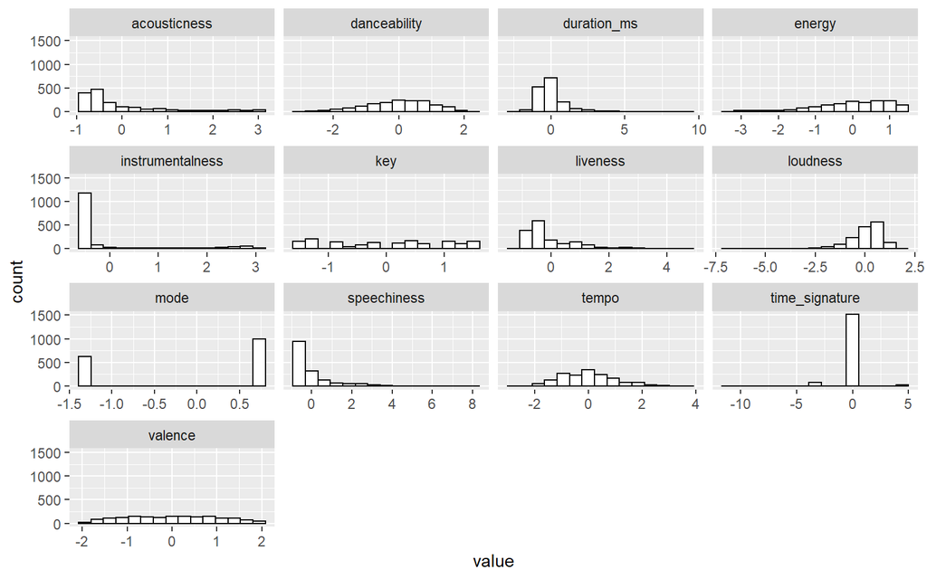

```r
data_scale %>%
    select_if(is.numeric) %>%
    pivot_longer(cols = -save, names_to = 'predictor') %>%
    ggplot() +
    geom_histogram(aes(x = value), bins = 15, color = 'black', fill = 'white') +
    facet_wrap(~predictor, scales = 'free_x')
```

Some variable are uniform, but some other could dont have a good distribution curve (some transformation on the feature like log or log(1+x) could be apply)

We can look at the correlation of the predictors with ‘save’:

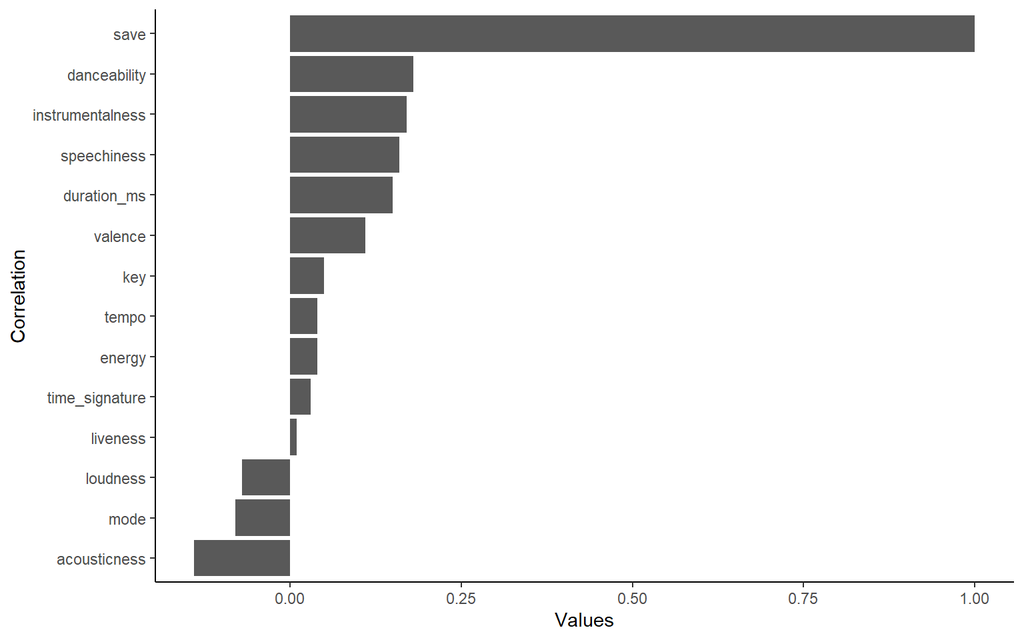

```r
data_scale.cor = round(cor(data_scale), 2)
cor_ = data.frame(data_scale.cor[,c("save")])
cor_$Category = row.names(cor_)
cor_$Values = cor_$data_scale.cor...c..save...


cor_ %>%
  ggplot(aes(reorder(Category, Values), Values)) +
    geom_col() +
    coord_flip() +
    labs(x = "Correlation") +
    theme_classic()
```

# PCA visualization

We use PCA evaluation to select the best predictors (less redondant information)

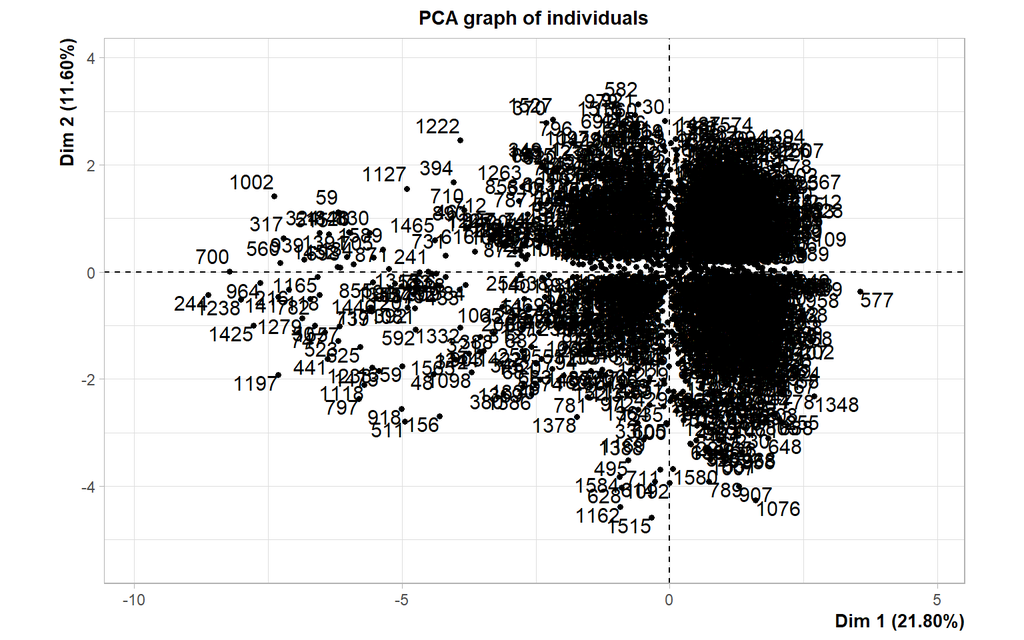

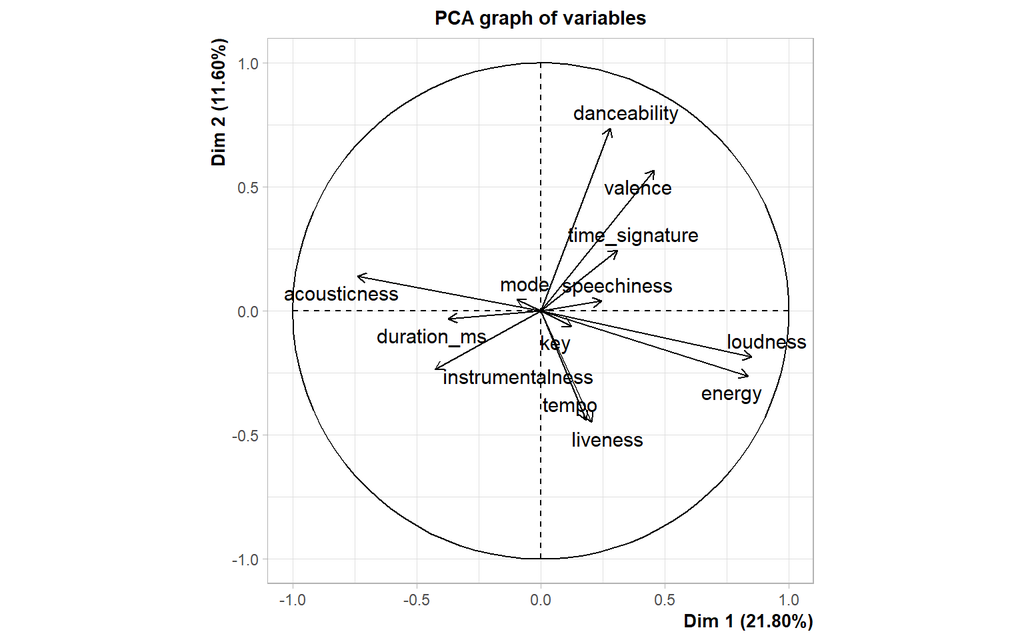

```r
tmp = data[,unlist(lapply(data, is.numeric))] %>% select(-c(save))
res.pca <-PCA(tmp, scale.unit = TRUE, graph = TRUE)
```

```r
summary(res.pca)
```

```
##
## Call:
## PCA(X = tmp, scale.unit = TRUE, graph = TRUE)
##
##
## Eigenvalues
##                        Dim.1   Dim.2   Dim.3   Dim.4   Dim.5   Dim.6   Dim.7
## Variance               2.834   1.508   1.346   1.123   1.025   0.992   0.898
## % of var.             21.802  11.596  10.356   8.640   7.886   7.630   6.909
## Cumulative % of var.  21.802  33.398  43.754  52.393  60.279  67.909  74.818
##                        Dim.8   Dim.9  Dim.10  Dim.11  Dim.12  Dim.13
## Variance               0.789   0.754   0.645   0.535   0.381   0.169
## % of var.              6.070   5.802   4.960   4.114   2.934   1.302
## Cumulative % of var.  80.888  86.690  91.649  95.763  98.698 100.000
##
## Individuals (the 10 first)
##                      Dist    Dim.1    ctr   cos2    Dim.2    ctr   cos2
## 1                |  3.190 | -1.401  0.043  0.193 |  0.655  0.018  0.042 |
## 2                |  2.895 |  1.094  0.026  0.143 |  0.565  0.013  0.038 |
## 3                |  2.163 |  1.072  0.025  0.246 |  0.845  0.029  0.153 |
## 4                |  1.790 |  0.735  0.012  0.169 | -0.944  0.037  0.278 |
## 5                |  2.752 |  1.141  0.028  0.172 | -1.537  0.097  0.312 |
## 6                |  3.686 |  1.132  0.028  0.094 |  1.084  0.048  0.086 |
## 7                |  2.783 |  2.232  0.109  0.643 | -0.044  0.000  0.000 |
## 8                |  3.039 |  1.091  0.026  0.129 | -1.012  0.042  0.111 |
## 9                |  2.810 |  1.631  0.058  0.337 | -0.359  0.005  0.016 |
## 10               |  2.744 |  1.022  0.023  0.139 |  0.637  0.017  0.054 |
##                   Dim.3    ctr   cos2
## 1                 1.466  0.099  0.211 |
## 2                 1.213  0.068  0.176 |
## 3                 0.009  0.000  0.000 |
## 4                -0.997  0.046  0.310 |
## 5                 0.523  0.013  0.036 |
## 6                 1.046  0.050  0.081 |
## 7                -0.307  0.004  0.012 |
## 8                 1.048  0.051  0.119 |
## 9                 1.230  0.070  0.192 |
## 10                0.122  0.001  0.002 |
##
## Variables (the 10 first)
##                     Dim.1    ctr   cos2    Dim.2    ctr   cos2    Dim.3    ctr
## acousticness     | -0.739 19.263  0.546 |  0.139  1.274  0.019 | -0.203  3.066
## danceability     |  0.281  2.781  0.079 |  0.738 36.080  0.544 |  0.231  3.955
## duration_ms      | -0.372  4.878  0.138 | -0.032  0.069  0.001 |  0.594 26.215
## energy           |  0.837 24.694  0.700 | -0.263  4.575  0.069 |  0.092  0.633
## instrumentalness | -0.426  6.408  0.182 | -0.235  3.661  0.055 |  0.465 16.059
## key              |  0.125  0.551  0.016 | -0.060  0.242  0.004 |  0.509 19.229
## liveness         |  0.206  1.493  0.042 | -0.449 13.370  0.202 |  0.059  0.263
## loudness         |  0.851 25.531  0.724 | -0.185  2.277  0.034 | -0.123  1.118
## mode             | -0.097  0.334  0.009 |  0.046  0.142  0.002 | -0.607 27.337
## speechiness      |  0.245  2.120  0.060 |  0.040  0.108  0.002 |  0.031  0.072
##                    cos2
## acousticness      0.041 |
## danceability      0.053 |
## duration_ms       0.353 |
## energy            0.009 |
## instrumentalness  0.216 |
## key               0.259 |
## liveness          0.004 |
## loudness          0.015 |
## mode              0.368 |
## speechiness       0.001 |
```

```r
get_eigenvalue(res.pca)
```

```
##        eigenvalue variance.percent cumulative.variance.percent
## Dim.1   2.8342066        21.801590                    21.80159
## Dim.2   1.5075359        11.596430                    33.39802
## Dim.3   1.3462343        10.355649                    43.75367
## Dim.4   1.1231657         8.639736                    52.39340
## Dim.5   1.0251339         7.885645                    60.27905
## Dim.6   0.9918462         7.629586                    67.90864
## Dim.7   0.8982186         6.909374                    74.81801
## Dim.8   0.7891027         6.070021                    80.88803
## Dim.9   0.7542318         5.801783                    86.68981
## Dim.10  0.6447354         4.959503                    91.64932
## Dim.11  0.5348353         4.114118                    95.76343
## Dim.12  0.3814390         2.934147                    98.69758
## Dim.13  0.1693145         1.302419                   100.00000
```

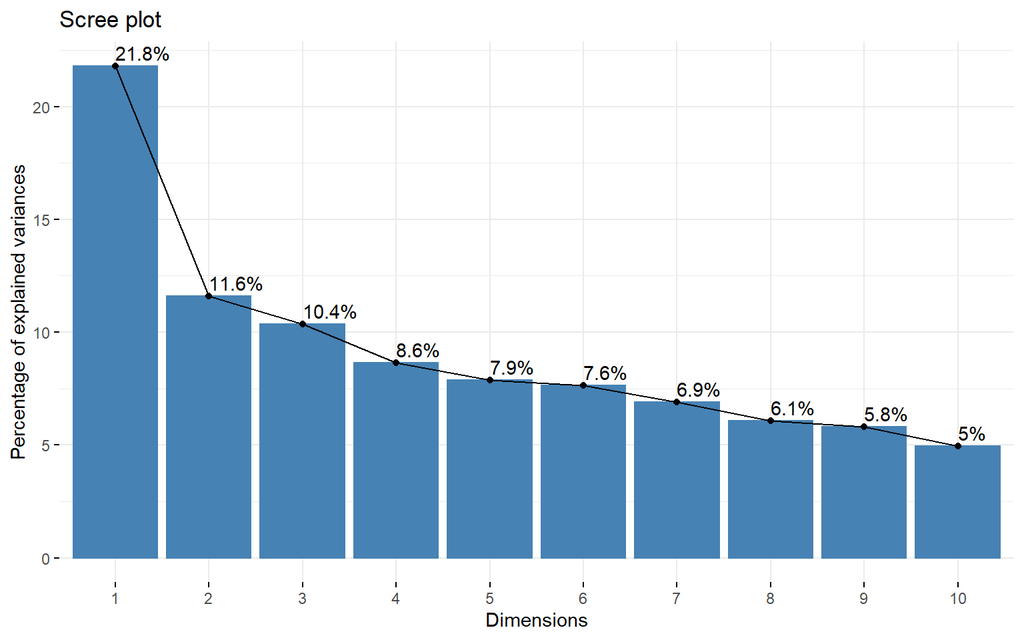

```r
fviz_eig(res.pca,addlabels = TRUE)
```

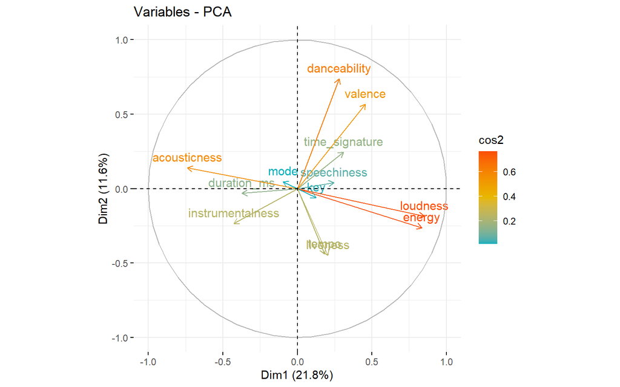

```r
#Plot the correlation circle using the fviz_pca_var function.
fviz_pca_var(res.pca, col.var = "cos2",
             gradient.cols = c("#00AFBB", "#E7B800", "#FC4E07"))
```

```r
var <- get_pca_var(res.pca)
var
```

```
## Principal Component Analysis Results for variables
##  ===================================================
##   Name       Description
## 1 "$coord"   "Coordinates for the variables"
## 2 "$cor"     "Correlations between variables and dimensions"
## 3 "$cos2"    "Cos2 for the variables"
## 4 "$contrib" "contributions of the variables"
```

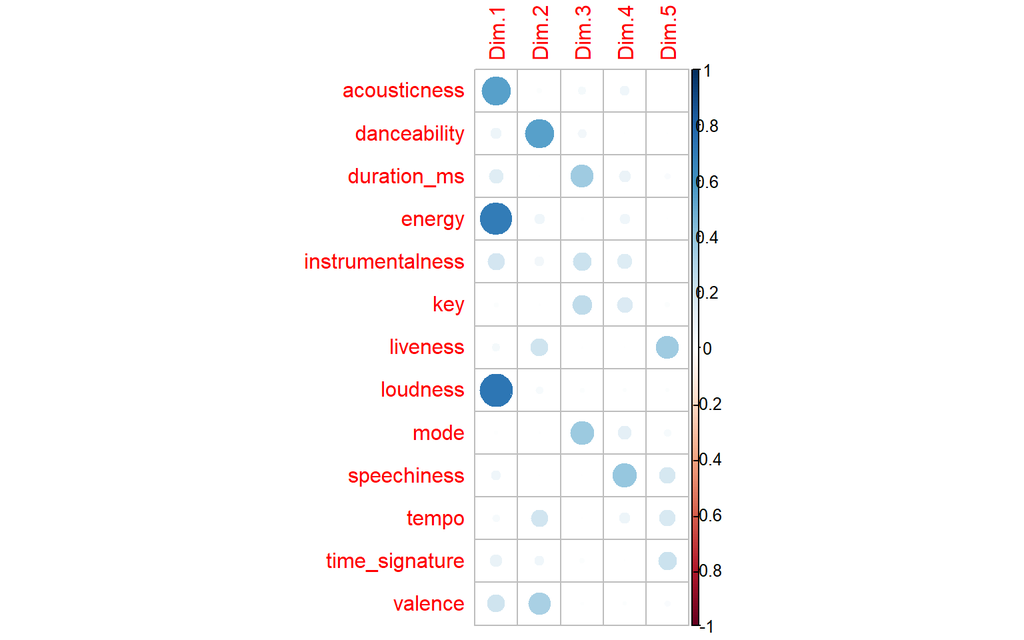

```r
library("corrplot")
corrplot(var$cos2)
```

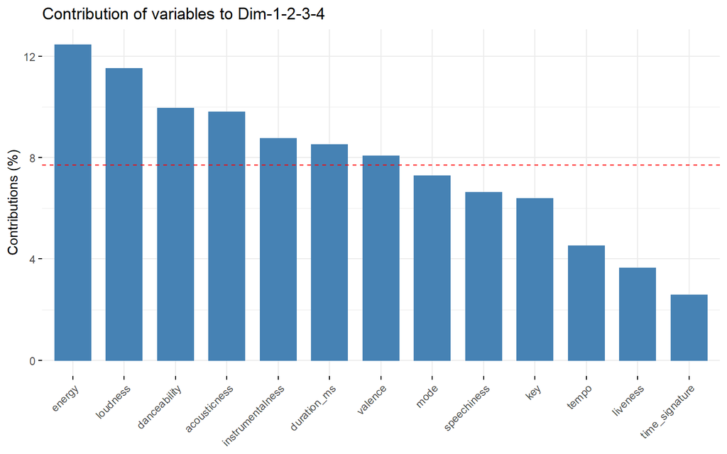

```r
fviz_contrib(res.pca, choice = "var", axes = 1:4)
```

# ML Model (for kaggle models we used all the features, in this session we look only to the selected features)

```r
df = data
df$save=as.factor(df$save)

sample = sample(1:nrow(df), nrow(df)*0.8)
cols = c("energy","loudness","danceability","acousticness","instrumentalness","duration_ms","mode","save")
training_data = df[sample, ] %>% select(cols)
testing_data = df[-sample, ] %>% select(cols)
```

## Choice of the model

we will be testing based on Accuracy :

Bagged CART RandomForest Stochastic Gradient Boosting

## Bagged CART

```r
fitControl_bag = trainControl(method = "repeatedcv",number = 8,repeats = 3)
model_tune_bag = train(as.factor(save) ~ ., data = training_data, method = "treebag", trControl = fitControl_bag)
model_tune_bag
```

```
## Bagged CART
##
## 1290 samples
##    7 predictor
##    2 classes: '0', '1'
##
## No pre-processing
## Resampling: Cross-Validated (8 fold, repeated 3 times)
## Summary of sample sizes: 1129, 1129, 1128, 1128, 1129, 1129, ...
## Resampling results:
##
##   Accuracy   Kappa
##   0.7338426  0.4674343
```

```r
predict2=predict(model_tune_bag,testing_data)
Accuracy(y_pred =predict2,y_true=testing_data$save)
```

```
## [1] 0.6842105
```

## RandomForest

```r
fitControl_RF = trainControl(method = "repeatedcv",number = 8,repeats = 3)
model_tune_RF = train(as.factor(save) ~ ., data = training_data, method = "rf", trControl = fitControl_RF)
model_tune_RF
```

```
## Random Forest
##
## 1290 samples
##    7 predictor
##    2 classes: '0', '1'
##
## No pre-processing
## Resampling: Cross-Validated (8 fold, repeated 3 times)
## Summary of sample sizes: 1129, 1128, 1129, 1128, 1129, 1129, ...
## Resampling results across tuning parameters:
##
##   mtry  Accuracy   Kappa
##   2     0.7439070  0.4878088
##   4     0.7439134  0.4876248
##   7     0.7390122  0.4779473
##
## Accuracy was used to select the optimal model using the largest value.
## The final value used for the model was mtry = 4.
```

```r
predict3=predict(model_tune_RF,testing_data)
Accuracy(y_pred =predict3,y_true=testing_data$save)
```

```
## [1] 0.6996904
```

## Stochastic Gradient Boosting

```r
fitControl = trainControl(method = "repeatedcv",number = 10,repeats = 3)
model_tune_boost = train(as.factor(save) ~ ., data = training_data, method = "gbm", trControl = fitControl,verbose = FALSE)
model_tune_boost
```

```
## Stochastic Gradient Boosting
##
## 1290 samples
##    7 predictor
##    2 classes: '0', '1'
##
## No pre-processing
## Resampling: Cross-Validated (10 fold, repeated 3 times)
## Summary of sample sizes: 1161, 1161, 1160, 1160, 1161, 1162, ...
## Resampling results across tuning parameters:
##
##   interaction.depth  n.trees  Accuracy   Kappa
##   1                   50      0.7144975  0.4292446
##   1                  100      0.7209156  0.4420489
##   1                  150      0.7273578  0.4549687
##   2                   50      0.7284214  0.4570733
##   2                  100      0.7464855  0.4932085
##   2                  150      0.7542518  0.5086504
##   3                   50      0.7335715  0.4676328
##   3                  100      0.7488251  0.4979026
##   3                  150      0.7550509  0.5102654
##
## Tuning parameter 'shrinkage' was held constant at a value of 0.1
##
## Tuning parameter 'n.minobsinnode' was held constant at a value of 10
## Accuracy was used to select the optimal model using the largest value.
## The final values used for the model were n.trees = 150, interaction.depth =
##  3, shrinkage = 0.1 and n.minobsinnode = 10.
```

```r
predict4=predict(model_tune_boost,testing_data)
Accuracy(y_pred =predict4,y_true=testing_data$save)
```

```
## [1] 0.6780186
```

## Now we will use RandomForest provides the best results

base random forest

```r
model_Random_Forest=randomForest(save~. ,
                                 data=training_data,
                                 importance = TRUE,
                                 proximity = TRUE)
model_Random_Forest
```

```
##
## Call:
##  randomForest(formula = save ~ ., data = training_data, importance = TRUE,      proximity = TRUE)
##                Type of random forest: classification
##                      Number of trees: 500
## No. of variables tried at each split: 2
##
##         OOB estimate of  error rate: 25.5%
## Confusion matrix:
##     0   1 class.error
## 0 472 160   0.2531646
## 1 169 489   0.2568389
```

```r
prediction_model_Random_Forest=predict(model_Random_Forest,testing_data)
Accuracy(y_pred =prediction_model_Random_Forest,y_true=testing_data$save)
```

```
## [1] 0.6934985
```

## We optimise randomForest

```r
importance(model_Random_Forest)
```

```
##                          0          1 MeanDecreaseAccuracy MeanDecreaseGini
## energy           40.389098  5.1385269            38.278448        105.25013
## loudness         41.162416 11.5459125            40.764239        117.97782
## danceability     25.971856 14.4804263            27.351869         99.70710
## acousticness     35.534755 -0.2899107            29.809118         97.70975
## instrumentalness 45.755027 20.3165342            47.064589        101.53751
## duration_ms      30.811001 11.2121492            28.237866        107.39864
## mode              5.164232  1.3407697             4.689682         12.59190
```

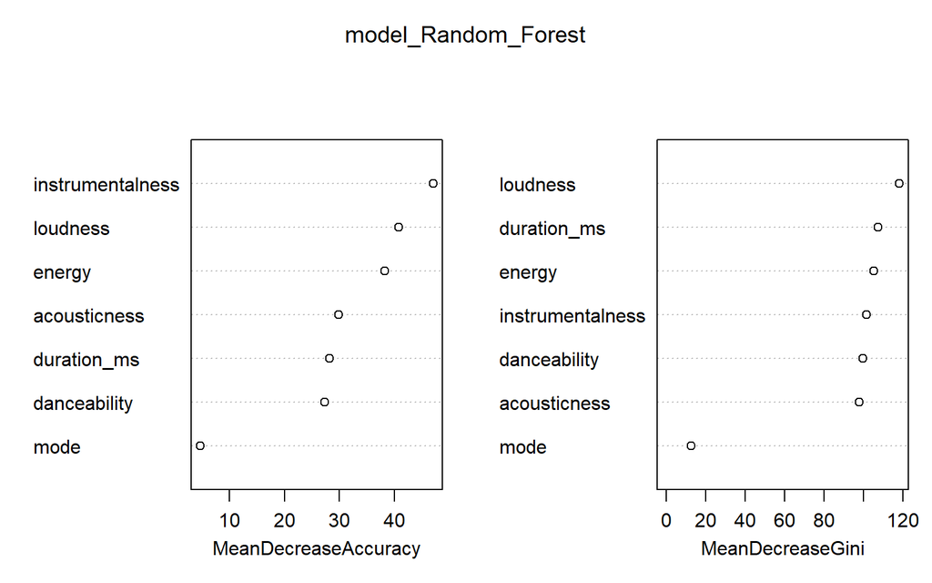

```r
varImpPlot(model_Random_Forest)
```

```r
#Create control function for training with 10 folds and keep 3 folds for training. search method is grid.
control <- trainControl(method='oob',
                        number=6,
                        search='grid',
                        adaptive = list(min = 5, alpha = 0.05, method = "gls", complete = TRUE))

#control2=trainControl(method = "repeatedcv",number = 10,repeats = 3)


#create tunegrid with 15 values from 1:15 for mtry to tunning model. Our train function will change number of entry variable at each split according to tunegrid.
tunegrid <- expand.grid(.mtry = (1:5))
rf_gridsearch <- train(save ~ . ,
                       data = training_data,
                       method = 'rf',
                       metric = 'Accuracy',
                       tuneGrid = tunegrid,
                       trControl=control)
print(rf_gridsearch)
```

```
## Random Forest
##
## 1290 samples
##    7 predictor
##    2 classes: '0', '1'
##
## No pre-processing
## Resampling results across tuning parameters:
##
##   mtry  Accuracy   Kappa
##   1     0.7310078  0.4628883
##   2     0.7434109  0.4868858
##   3     0.7449612  0.4898587
##   4     0.7449612  0.4897949
##   5     0.7364341  0.4726210
##
## Accuracy was used to select the optimal model using the largest value.
## The final value used for the model was mtry = 3.
```

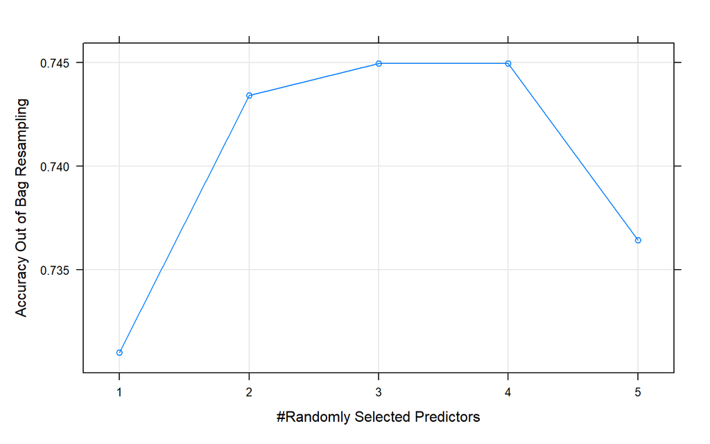

```r
plot(rf_gridsearch)
```

```r
predict5=predict(rf_gridsearch,testing_data)
Accuracy(y_pred =predict5,y_true=testing_data$save)
```

```
## [1] 0.7120743
```

RandomForest gives us the best and more stable prediction here

# Test with full dataset training and testing (for CSV output)

```r
df <- read.csv("C:/Users/Papa/Documents/R_eval/train.csv")
cols = c("energy","loudness","danceability","acousticness","instrumentalness","duration_ms","mode","save")
df = df %>% select(cols)

cols2 = c("energy","loudness","danceability","acousticness","instrumentalness","duration_ms","mode")
df_test <- read.csv("C:/Users/Papa/Documents/R_eval/test.csv")
df_test = df_test %>% select(cols2)

training_data = df
testing_data = df_test



control <- trainControl(method='oob',
                        number=6,
                        search='grid',
                        adaptive = list(min = 5, alpha = 0.05, method = "gls", complete = TRUE))

tunegrid <- expand.grid(.mtry = (1:5))
rf_gridsearch <- train(as.factor(save) ~ .,
                       data = training_data,
                       method = 'rf',
                       metric = 'Accuracy',
                       tuneGrid = tunegrid,
                       trControl=control)


prediction_final=predict(rf_gridsearch,testing_data)
```

```r
to_be_submitted = data.frame(id=rownames(df_test), save=prediction_final)
write.csv(to_be_submitted , file = "to_be_submitted.csv", row.names = F)
```